# Introduction

In this notebook we will try to find the flow of the Vélib rides based on the information we have in the public vélib API

### What is a flow map ?

A flow map is a type of thematic map that uses linear symbols to represent movement.

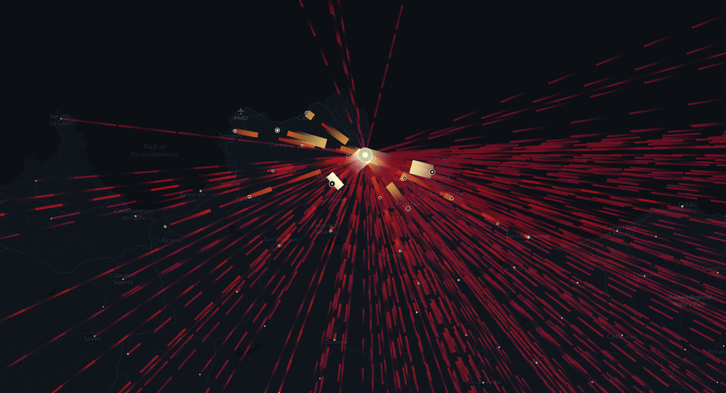

### The Vélib API

The Vélib API used in the android application gives more infomation than the one used in the https://www.velib-metropole.fr/map , because it gives the id of every bike (bikeName in the json response).

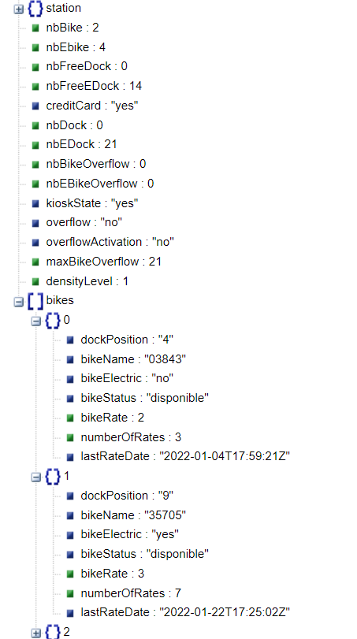

So, by monitoring and saving these data every 10 min we can know that a bike moved from a station to another

### Example :

#### At 7:00 PM :

The bike 03843 appears as available in the station : "Jourdan - Stade Charléty"

#### At 07:10 PM :

The same bike 03843 doesn't appear in any station of the Vélib stations, it has been probably taken by a user to make a ride

#### At 07:20 PM :

The same bike still doesn't appear, It is still used by its rider.

#### At 07:30 PM :

The bike 03843 appears among the bikes parked in the station : "Saint-Sulpice"

#### Conclusion :

Only by saving every 10 minutes the data about the bikes parked in every station, we were able to know that the bike 03843 moved from station "Jourdan - Stade Charléty" to station "Saint-Sulpice"